# Google Data Analytics Capstone Project: Bella Beat

Santanu

12/12/2023

## Introduction

This is my Google Data Analytics Capstone Project for Case Study 2 - BellaBeat.

## Scenario

You are a junior data analyst working on the marketing analyst team at Bellabeat, a high-tech manufacturer of health-focused products for women. Bellabeat is a successful small company, but they have the potential to become a larger player in the global [smart device](https://en.wikipedia.org/wiki/Smart_device) market. Urška Sršen, cofounder and Chief Creative Officer of Bellabeat, believes that analyzing smart device fitness data could help unlock new growth opportunities for the company. You have been asked to focus on one of Bellabeat’s products and analyze smart device data to gain insight into how consumers are using their smart devices. The insights you discover will then help guide marketing strategy for the company. You will present your analysis to the Bellabeat executive team along with your high-level recommendations for Bellabeat’s marketing strategy.

## Stakeholders

Urška Sršen: Co-founder and Chief Creative Officer. Sando Mur: Mathematician and Co-founder. Bellabeat Marketing Analytics Team: Data analysts responsible for guiding marketing strategy.

- **Products**

Bellabeat App: Tracks activity, sleep, stress, menstrual cycle, and mindfulness. Leaf: Classic wellness tracker for activity, sleep, and stress. Time: Wellness watch tracking activity, sleep, and stress. Spring: Smart water bottle tracking daily hydration. Bellabeat Membership: Subscription-based program offering personalized guidance.

## About The Company

Founded in 2013 by Urška Sršen and Sando Mur, Bellabeat combines artistry and technology to empower women with health insights. The company has expanded globally, offering a range of products available online and through various retailers. Digital marketing is a key focus, with investments in platforms like Google, Facebook, Instagram, Twitter, and YouTube.

## 1. Ask

### Business Objective

Analyze non-Bellabeat smart device usage data, specifically FitBit trackers, to influence the target market for Bellabeat’s Time watch.

## 2. Prepare

### Location of Data

The data used in this project is from Kaggle: [FitBit Fitness Tracker Data](https://www.kaggle.com/datasets/arashnic/fitbit).

### Data Credibility, licensing and integrity

This Kaggle data set contains personal fitness tracker from thirty fitbit users. The data was collected by a survey sent via Amazon Mechanical Turk between 03.12.2016-05.12.2016. CC0: Public Domain, made available by [Möbius](https://www.kaggle.com/arashnic). It was last updated over a year ago.

### Data Organization

- I am focusing on the daily time frame of the data as the goal on my analysis is reliant on the trends in the day to day smart device usage.
- I will be using all the daily activity, sleep, and weight data to show trends and pattern that will hopefully help us in seeing some opportunity in improving Bellabeat marketing strategy.
- For this project, It could be easily be done in Excel or Google Sheets. However, I chose to use RStudio Desktop to help get comfortable and learn more about this language.

```r
# Set CRAN mirror
options(repos = "http://cran.us.r-project.org")

# Install and load the package
install.packages(c("tidyverse", "dplyr", "ggplot2", "tidyr", "skimr", "lubridate", "janitor"))
install.packages("readr")
library(tidyverse)
library(dplyr)
library(ggplot2)
library(tidyr)
library(skimr)
library(lubridate)
library(janitor)
library(readr)
```

```r
#Importing data

# Install and load the readr package
install.packages("readr")
library(readr)


activity <- read_csv("C:/Users/bhumi/Desktop/Fitabase Data 4.12.16-5.12.16/dailyActivity_merged.csv")
calories <- read_csv("C:/Users/bhumi/Desktop/Fitabase Data 4.12.16-5.12.16/dailyCalories_merged.csv")
intensities <- read_csv("C:/Users/bhumi/Desktop/Fitabase Data 4.12.16-5.12.16/dailyIntensities_merged.csv")
steps <- read.csv("C:/Users/bhumi/Desktop/Fitabase Data 4.12.16-5.12.16/dailySteps_merged.csv")
sleeps <- read.csv("C:/Users/bhumi/Desktop/Fitabase Data 4.12.16-5.12.16/sleepDay_merged.csv")
weights <- read_csv("C:/Users/bhumi/Desktop/Fitabase Data 4.12.16-5.12.16/weightLogInfo_merged.csv")
```

## 3.Process

### Cleaning and formatting

I used the glimpse() on each dataset to get a general understanding of the content, data, formats, and data integrity.

```r
#I will only be showing one of the data set.
glimpse(activity)
```

```
## Rows: 940
## Columns: 15
## $ Id                       <dbl> 1503960366, 1503960366, 1503960366, 150396036…
## $ ActivityDate             <chr> "4/12/2016", "4/13/2016", "4/14/2016", "4/15/…
## $ TotalSteps               <dbl> 13162, 10735, 10460, 9762, 12669, 9705, 13019…
## $ TotalDistance            <dbl> 8.50, 6.97, 6.74, 6.28, 8.16, 6.48, 8.59, 9.8…
## $ TrackerDistance          <dbl> 8.50, 6.97, 6.74, 6.28, 8.16, 6.48, 8.59, 9.8…
## $ LoggedActivitiesDistance <dbl> 0, 0, 0, 0, 0, 0, 0, 0, 0, 0, 0, 0, 0, 0, 0, …
## $ VeryActiveDistance       <dbl> 1.88, 1.57, 2.44, 2.14, 2.71, 3.19, 3.25, 3.5…
## $ ModeratelyActiveDistance <dbl> 0.55, 0.69, 0.40, 1.26, 0.41, 0.78, 0.64, 1.3…
## $ LightActiveDistance      <dbl> 6.06, 4.71, 3.91, 2.83, 5.04, 2.51, 4.71, 5.0…
## $ SedentaryActiveDistance  <dbl> 0, 0, 0, 0, 0, 0, 0, 0, 0, 0, 0, 0, 0, 0, 0, …
## $ VeryActiveMinutes        <dbl> 25, 21, 30, 29, 36, 38, 42, 50, 28, 19, 66, 4…
## $ FairlyActiveMinutes      <dbl> 13, 19, 11, 34, 10, 20, 16, 31, 12, 8, 27, 21…
## $ LightlyActiveMinutes     <dbl> 328, 217, 181, 209, 221, 164, 233, 264, 205, …
## $ SedentaryMinutes         <dbl> 728, 776, 1218, 726, 773, 539, 1149, 775, 818…
## $ Calories                 <dbl> 1985, 1797, 1776, 1745, 1863, 1728, 1921, 203…
```

After reviewing the data, I noticed that the activity data set is a merged data set of steps, intensities, and calories. So, I will be using only the activity, sleeps, and weights data sets.

Verifying number of users and cleaning duplicates

```r
n_distinct(activity$Id)
```

```
## [1] 33
```

```r
n_distinct(sleeps$Id)
```

```
## [1] 24
```

```r
n_distinct(weights$Id)
```

```
## [1] 8
```

Off of the number of unique users, we can see the number of users that are using each of the features:

- Steps Count feature: 33 (100%)
- Sleep Monitor feature: 24 (73%)
- Weight Tracking feature: 8 (24%)

I have decided to not use the weight tracking data for further analysis as there are not enough users for it to be reliable data.

Check for duplicates

```r
sum(duplicated(activity))
```

```
## [1] 0
```

```r
sum(duplicated(sleeps))
```

```
## [1] 3
```

According to the content explanation of the data on Kaggle, the data collected was of thirty users and the above shows 33 distinct Ids. Tabulation of Id to dig deeper.

```r
tabyl(activity, Id)
```

```
##          Id  n     percent
##  1503960366 31 0.032978723
##  1624580081 31 0.032978723
##  1644430081 30 0.031914894
##  1844505072 31 0.032978723
##  1927972279 31 0.032978723
##  2022484408 31 0.032978723
##  2026352035 31 0.032978723
##  2320127002 31 0.032978723
##  2347167796 18 0.019148936
##  2873212765 31 0.032978723
##  3372868164 20 0.021276596
##  3977333714 30 0.031914894
##  4020332650 31 0.032978723
##  4057192912  4 0.004255319
```

[output cut: 19 more lines]

Clean up some of the data

```r
#removing duplicates, columns in activity data set that I will not be using for my analysis: "LoggedActivitiesDistance" and "TrackerDistance", and removing users that has less than 20 entry dates "4057192912, 2347167796, 8253242879"
trimmed_activity <- activity %>%
  subset(!(Id %in% c(4057192912, 2347167796, 8253242879)))%>%
  select(-LoggedActivitiesDistance, -TrackerDistance)

sleeps_cleaned <- sleeps %>%
  distinct()
```

#### Initial Findings:

1. FitBit’s main feature, activity tracking, has a 100% usage rate.
2. Approximately 73% of users utilize the sleep tracking feature.
3. The majority of users fall into either the Sedentary or Very Active category based on daily steps.

## 4. Analyze

### Segmenting users by daily steps

User daily activity level will be segmented into four groups as per the [10,000-step protocol](https://www.10000steps.org.au/articles/counting-steps/#:~:text=Low%20active%20is%205%2C000%20to,active%20is%20more%20than%2012%2C500). The daily amount of steps of each user each day will give us an idea of their activity level. The categories are as follow:

- Sedentary - Less than 5000 steps per day.
- Lightly active - Between 5000 and 7499 steps per day.
- Fairly active - Between 7500 and 9999 steps per day.
- Very active - More than 10000 steps per day.

```r
# Segmenting each user's activity level per day

segmented_activity <- trimmed_activity %>%
  mutate(Activity_level = case_when(TotalSteps <= 5000 ~ "1.Sedentary", TotalSteps > 5000 & TotalSteps <= 7499 ~ "2.Lightly active", TotalSteps >= 7500 & TotalSteps <= 9999 ~ "3.Fairly active", TotalSteps >= 10000 ~ "4.Very active"))

head(segmented_activity)
```

```
## # A tibble: 6 × 14
##           Id ActivityDate TotalSteps TotalDistance VeryActiveDistance
##        <dbl> <chr>             <dbl>         <dbl>              <dbl>
## 1 1503960366 4/12/2016         13162          8.5                1.88
## 2 1503960366 4/13/2016         10735          6.97               1.57
## 3 1503960366 4/14/2016         10460          6.74               2.44
## 4 1503960366 4/15/2016          9762          6.28               2.14
## 5 1503960366 4/16/2016         12669          8.16               2.71
## 6 1503960366 4/17/2016          9705          6.48               3.19
## # ℹ 9 more variables: ModeratelyActiveDistance <dbl>,
## #   LightActiveDistance <dbl>, SedentaryActiveDistance <dbl>,
## #   VeryActiveMinutes <dbl>, FairlyActiveMinutes <dbl>,
## #   LightlyActiveMinutes <dbl>, SedentaryMinutes <dbl>, Calories <dbl>,
## #   Activity_level <chr>
```

### Getting the percentage in each category and plotting bar graph.

```r
segmented_activity %>%
  count(Activity_level) %>%
  mutate(percentage = n / nrow(segmented_activity)) -> segmented_activity2
head(segmented_activity2)
```

```
## # A tibble: 4 × 3
##   Activity_level       n percentage
##   <chr>            <int>      <dbl>
## 1 1.Sedentary        294      0.327
## 2 2.Lightly active   160      0.178
## 3 3.Fairly active    154      0.171
## 4 4.Very active      291      0.324
```

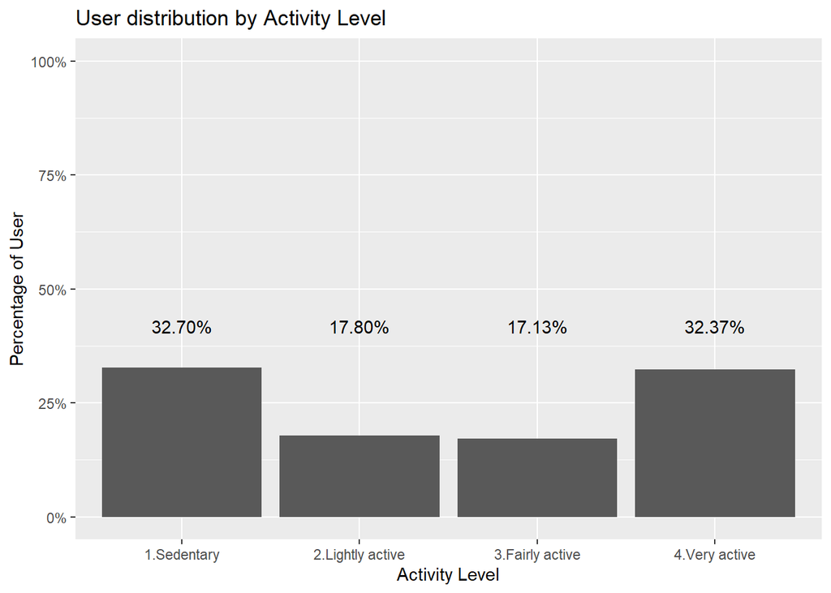

```r
ggplot(segmented_activity2, aes(x = Activity_level, y = percentage)) +
    geom_bar(stat = "identity")+
    geom_text(aes(label = scales::percent(percentage),y= ..prop..), stat= "count",vjust = 20)+
    labs(title="User distribution by Activity Level", x = "Activity Level", y= "Percentage of User")+
    scale_y_continuous(labels=scales::percent)
```

Bar graph illustrating the percentage of users in each activity level category, ranging from Sedentary to Very Active.

### Plotting a histogram to see the districution of users sleeping

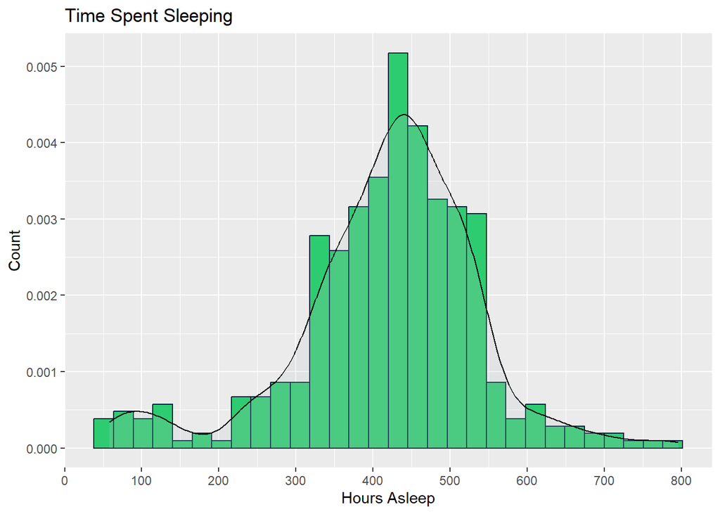

```r
ggplot(sleeps_cleaned,aes(x=TotalMinutesAsleep)) +
  geom_histogram(aes(y=..density..), colour="#001F3F", fill="#2ECC71", bins = 30)+
  geom_density(alpha=.2, fill="#BDC3C7")+
  labs(title = "Time Spent Sleeping", x= "Hours Asleep", y= "Count")+
  scale_x_continuous(breaks = seq(0, 800, 100))
```

Histogram depicting the distribution of users based on the total minutes spent asleep, providing insights into sleep patterns.

### Plotting a histogram to see the districution of users spent time in bed

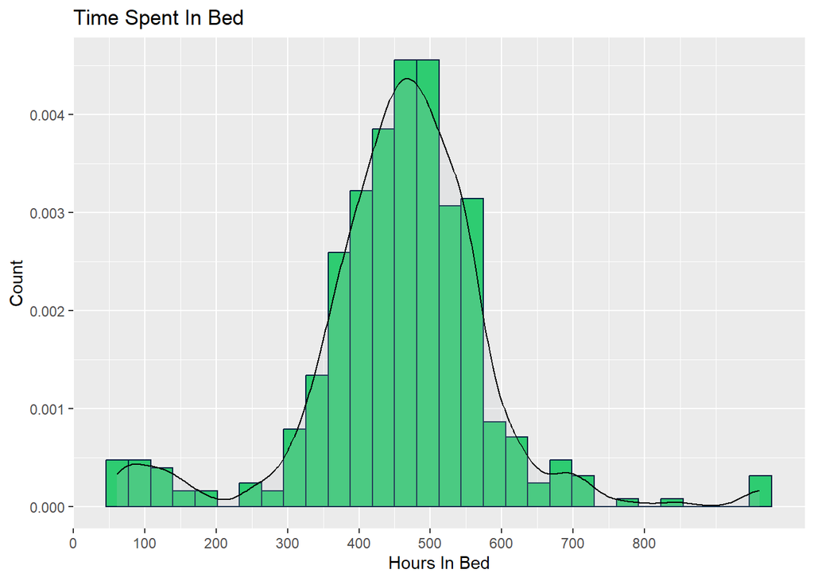

```r
ggplot(sleeps_cleaned, aes(x=TotalTimeInBed)) +
  geom_histogram(aes(y=..density..),colour="#001F3F", fill="#2ECC71", bins = 30)+
  geom_density(alpha=.2, fill="#BDC3C7")+
  labs(title = "Time Spent In Bed", x= "Hours In Bed", y= "Count")+
  scale_x_continuous(breaks = seq(0, 800, 100))
```

Histogram and density plot showcasing the distribution of users according to the total time spent in bed, offering insights into users’ bedtime habits.

## Share

### Insights

1. Weight tracking feature usage is low; consider making it more user-friendly.
2. Sleep feature is popular; explore improvements in comfort and battery life.
3. Focus marketing efforts on the steps/fitness tracker, given its high usage.

### Recomendation

1. Emphasize the ease of use for the weight tracking feature in marketing materials.
2. Consider product enhancements to improve comfort and battery life for the sleep feature.
3. Prioritize marketing campaigns highlighting the steps/fitness tracker to target potential consumers effectively.